# HW 32

## James Camacho

We use something similar to the Crank-Nicolson method. Let

$$F(U) = \Delta U + \frac{1}{\mu}U(1-U)(U-a),$$

where $\Delta U$ uses the four-point stencil (second-order accurate). The $U$ update is

$$\frac{U^{n+1}-U^n}{\Delta t} = \frac{1}{2}\left[F(U^n) + F(U^{n+1})\right].$$

Let

$$G(V) = \Delta V - V,$$

so the $V$ update is

$$\frac{V^{n+1} - V^n}{\Delta t} = \frac{1}{2}\left[G(V^n) + G(V^{n+1})\right] + \frac{1}{2}\left[U^n + U^{n+1}\right] + b.$$

### Updating U

Let $x = U^{n+1}$ and

$$c = U^n + \frac{\Delta t}{2} F(U^n),$$

then we need to solve the nonlinear system

$$x=\frac{\Delta t}{2} F(x) + c.$$

If we were to use a quasi-Newton method (say Broyden's bad method), we would need an $n^2\times n^2$ dense Jacobian matrix, which would take $O(n^6)$ time to solve. Given $n\approx 10^2$, this is completely infeasible. Even if we use some ADI method along with Crank-Nicolson, it would still be $O(n^3)$, which means on the order of $10^6$ operations. That's about one second *per iteration* of Broyden's bad method. Instead, we use an iterative method:

$$Z(x) = \frac{\Delta t}{2} F(x) + c,$$

and converge to $Z(x) = x$. If we just use one iteration, we would get Heun's method (explicit trapezoidal method).

### Updating V

Updating $V$ is much easier as it's linear. Let $\nu = \frac{\Delta t}{2\Delta x\Delta y}.$ Rearranging we have

$$(1+2\nu + \Delta t/2)V^{n+1}_{i,j} - \nu\sum_{sym}V^{n+1}_{i+1,j} = (1-2\nu - \Delta t/2)V^{n+1}_{i,j} + \nu\sum_{sym}V^{n+1}_{i+1,j} + \frac{\Delta t}{2}\left[U^n + U^{n+1}\right] + b\Delta t.$$

### Dimension size?

It's two-dimensional, and each dimension has $10^2$ nodes. Solving the system of equations for $V$ takes $O(n^{\frac32})$ time, so putting $n=10^2\times 10^2$ that's $10^6$, which is about a full second in Python. We can alternate spacial dimensions to bring it down to an order of $10^3$ operations.

This is why we have $2\nu$ not $4\nu$ above—we're only taking the "Laplacian" in one direction at a time. Also, it means we'll have to modify the forcing functions slightly to only be half the force, that way it's the full force when you add in both directions.

### Boundary Conditions

We're just assuming it's all Dirichlet as that's the easiest to implement.

# HW 33

```python
import numpy as np
import scipy.sparse
from scipy.linalg import solve_banded

import matplotlib.pyplot as plt
import seaborn as sns

import cv2
```

```python
def solve(U, V, a, b, mu, dt, T, save_every=None):
    """
    Constants
    """
    Nx, Ny = U.shape
    Nt = round(T / dt)

    dx = 1 / (Nx + 1)
    dy = 1 / (Ny + 1)
    nu = dt / 2 / dx / dy

    """
    Build Matrices
    """

    # Laplacian assuming we flatten in U[x, y] form.
    xy0 = [-2] * Nx * Ny
    xy1 = ([1] * (Nx - 1) + [0]) * Ny

    Lxy = scipy.sparse.diags([xy0, xy1, xy1], (0, 1, -1))

    # Laplacian assuming we flatten in U[y, x] form.
    yx0 = [-2] * Nx * Ny
    yx1 = ([1] * (Ny - 1) + [0]) * Nx
    Lyx = scipy.sparse.diags([yx0, yx1, yx1], (0, 1, -1))

    # RHS of V update
    xy0 = [1-2*nu] * Nx * Ny
    xy1 = ([nu] * (Nx - 1) + [0]) * Ny

    yx0 = [1-2*nu] * Nx * Ny
    yx1 = ([nu] * (Ny - 1) + [0]) * Nx

    V_RHS_xy = scipy.sparse.diags([xy0, xy1, xy1], (0, 1, -1))
    V_RHS_yx = scipy.sparse.diags([yx0, yx1, yx1], (0, 1, -1))

    # LHS of V update
    xy0 = [0] + (([-nu] * (Nx - 1) + [0]) * Ny)[:-1]
    xy1 = [1+2*nu-dt/2] * Nx * Ny
    xy2 = ([0] + [-nu] * (Nx - 1)) * Ny

    yx0 = [0] + (([-nu] * (Ny - 1) + [0]) * Nx)[:-1]
    yx1 = [1+2*nu+dt/2] * Nx * Ny

    V_LHS_xy = [xy0, xy1, xy0]
    V_LHS_yx = [yx0, yx1, yx0]

    """
    Update Functions
    """

    def F(U, mode="xy"):
        if mode not in ["xy", "yx"]:
            raise Exception("Mode must be 'xy' or 'yx'.")
        if mode == "xy":
            laplace = Lxy @ U
        elif mode == "yx":
            laplace = Lyx @ U

        force = U * (1-U) * (U-a) / mu
        force = force / 2
        return laplace + force

    def update_U(U, mode="xy", err=1e-5, max_iters=10):
        if mode not in ["xy", "yx"]:
            raise Exception("Mode must be 'xy' or 'yx'.")

        shape = U.shape
        U = U.flatten()

        c = U + dt/2 * F(U, mode=mode)
        def Z(x):
            return dt/2 * F(x, mode=mode) + c

        for i in range(max_iters):
            prev_U = U
            U = Z(U)
            if max(abs(U/prev_U - 1)) < err:
                break
        return U.reshape(shape)


    def update_V(V, U_prev, U, mode="xy"):
        if mode not in ["xy", "yx"]:
            raise Exception("Mode must be 'xy' or 'yx'.")

        shape = V.shape
        V = V.flatten()
        U_prev = U_prev.flatten()
        U = U.flatten()

        force = dt/2 * (U_prev + U) + b * dt
        force = force / 2
        if mode == "xy":
            RHS = V_RHS_xy @ V + force
            return solve_banded((1, 1), V_LHS_xy, RHS).reshape(shape)
        elif mode == "yx":
            RHS = V_RHS_yx @ V + force
            return solve_banded((1, 1), V_LHS_yx, RHS).reshape(shape)

    def ADI(U, V, mode="xy"):
        if mode not in ["xy", "yx"]:
            raise Exception("Mode must be 'xy' or 'yx'.")

        U_prev = U
        U = update_U(U, mode=mode)
        U = update_U(U, mode=mode[::-1])
        V = update_V(V, U_prev, U, mode=mode)
        V = update_V(V, U_prev, U, mode=mode[::-1])

        return U, V

    """
    Solve
    """

    mode = "xy"
    t = 0
    Us = []
    Vs = []
    ts = []
    for i in range(Nt):
        if save_every and i % save_every == 0:
            ts.append(t)
            if i % 2:
                Us.append(U.T)
                Vs.append(V.T)
            else:
                Us.append(U)
                Vs.append(V)
        U, V = ADI(U, V, mode)
        mode = mode[::-1]
        U = U.T
        V = V.T
        t += dt

    if save_every is None:
        return U, V, t

    if (Nt - 1) % save_every:
        if Nt % 2:
            U = U.T
            V = V.T

        Us.append(U)
        Vs.append(V)
        ts.append(t)

    return Us, Vs, ts
```

```python
# Initialize values
a = 0.34
b = -0.045
mu = 0.08

Nx = Ny = 100
x = np.linspace(0, 1, Nx)
y = np.linspace(0, 1, Ny)
xy = np.meshgrid(x, y)
U = np.sin(2*np.pi*xy[0]) + np.cos(2*np.pi*xy[1]) + np.exp((xy[0]+xy[1]))
U /= np.amax(abs(U))
V = np.zeros(U.shape)

dt = 0.1/np.amax(U)/max(Nx, Ny) # To satisfy CFL condition
print("dt =", dt)

# Calculate U, V.

T = 1
Us, Vs, ts = solve(U, V, a, b, mu, dt, T, save_every=250)
```

```
dt = 0.001
```

## U and V Converging

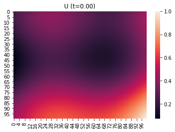

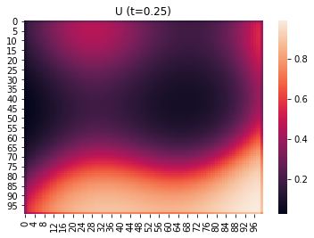

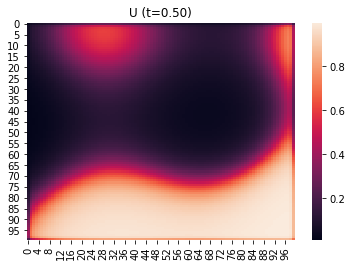

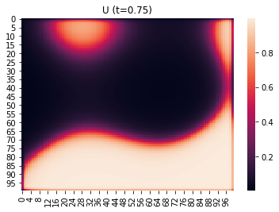

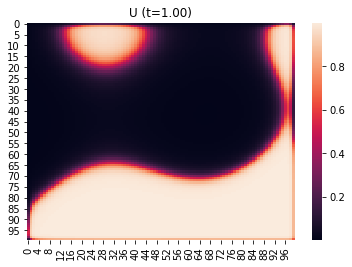

```python
for U, t in zip(Us, ts):
    plt.title("U (t=%.2f)" % t)
    sns.heatmap(U)
    plt.show()
```

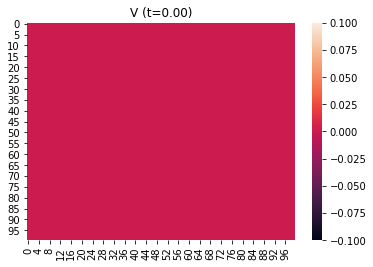

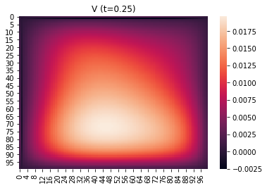

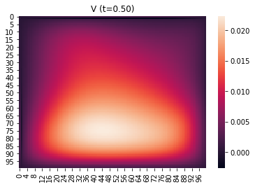

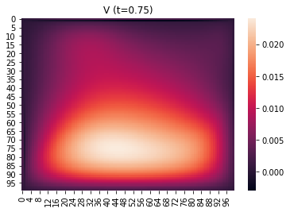

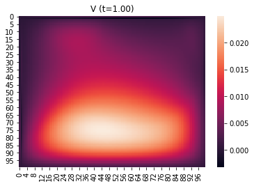

```python
for V, t in zip(Vs, ts):
    plt.title("V (t=%.2f)" % t)
    sns.heatmap(V)
    plt.show()
```

# HW 34

### Convergence Test—Time

We can see from the graphs below that it converges to $U$ on order $O(\Delta t)$ and to $V$ on order $O(\Delta t^{2})$.

```python
T = 0.1

Us, Vs = [], []
ts = [0.005, 0.001, 0.0005, 0.0001]

for dt in ts:
    U = np.sin(2*np.pi*xy[0]) + np.cos(2*np.pi*xy[1]) + np.exp((xy[0]+xy[1]))
    U /= np.amax(abs(U))
    V = np.zeros(U.shape)

    U, V, t = solve(U, V, a, b, mu, dt, T)
    Us.append(U)
    Vs.append(V)
```

```
Slope = 1.08
```

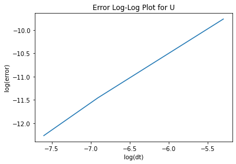

```python
# Errors - U

def error(U, true_U):
    return np.linalg.norm((U - true_U).flatten() / np.prod(U.shape)**0.5)

e = [error(U, Us[-1]) for U in Us[:-1]]
x = ts[:-1]

print("Slope = %.2f" % np.polyfit(np.log(x), np.log(e), deg=1)[0])
plt.title("Error Log-Log Plot for U")
plt.plot(np.log(x), np.log(e))
plt.xlabel("log(dt)")
plt.ylabel("log(error)")
plt.show()
```

```
Slope = 1.96
```

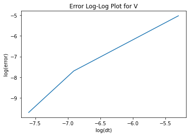

```python
# Errors - V

def error(V, true_V):
    return np.linalg.norm((V - true_V).flatten() / np.prod(V.shape)**0.5)

e = [error(V, Vs[-1]) for V in Vs[:-1]]
x = ts[:-1]

print("Slope = %.2f" % np.polyfit(np.log(x), np.log(e), deg=1)[0])
plt.title("Error Log-Log Plot for V")
plt.plot(np.log(x), np.log(e))
plt.xlabel("log(dt)")
plt.ylabel("log(error)")
plt.show()
```

### Convergence Test—Space

We can see from the graph below that it converges to $U$ on order $O(\Delta x)$.

```python
dt = 1e-3
T = 0.5

Ns = [10, 25, 50, 100]
Us, Vs = [], []

for N in Ns:
    Nx = N
    Ny = 25
    x = np.linspace(0, 1, Nx)
    y = np.linspace(0, 1, Ny)
    xy = np.meshgrid(x, y)
    U = 0.5 - ((xy[0] - 0.5)**2 + (xy[1] - 0.5)**2)
    U /= np.amax(abs(U))
    V = np.zeros(U.shape)

    U, V, t = solve(U, V, a, b, mu, dt, T)
    Us.append(U)
    Vs.append(V)
```

```
Slope = 0.97
```

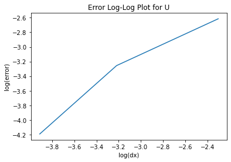

```python
# Errors - U

def error(U):
    true_U = cv2.resize(Us[-1], dsize=U.T.shape)
    return np.mean(abs(U - true_U))

e = [error(U) for U in Us[:-1]]
x = Ns[:-1]

print("Slope = %.2f" % np.polyfit(-np.log(x), np.log(e), deg=1)[0])
plt.title("Error Log-Log Plot for U")
plt.plot(-np.log(x), np.log(e))
plt.xlabel("log(dx)")
plt.ylabel("log(error)")
plt.show()
```